# Advanced spatial R workshop

Tobias Andermann

9/27/2019

## Accessing biodiveristy data through web services (IUCN)

Dependencies:

```r
library(raster)
library(sf)
```

In this exercise we are going to test which predictors are spatially significantly correlated with a biological variable. For example you would apply the tools we are covering in this workshop if you want to test if species diversity in your studied organism group is significantly correlated with temperature, precipitation, predator diversity, etc. While this is a common operation in particular in marco-ecological/-evolutionary studies, there are several caveats that one needs to account for. Here we will deal with the main ones, which are namely raster projection, testing for and accounting for spatial autocorrelation and applying different models (namely GLM and SAR) for statistical testing.

In this scenario we will check which environmental predictors have a significant influence on mammal species diversity, i.e. what is driving hgiher or lower mammal diversity (e.g. do warmer areas have higher diversity than colder ones, wetter than drier, …)

### The response variable

In our example mammal species diversity is the response variable, i.e. we want to figure out how species diversity responds to different predictors. You will need to produce the species diversity raster by adding up the presence/absence rasters belonging to each of the species of your mammal group of choice.

For selecting the species names belonging to your chosen group (order, family or genus), you can use the following taxonomy information available from the [Phylacine database](https://megapast2future.github.io/PHYLACINE_1.2/):

```r
mammal_taxonomic_data = read.csv('../data/Data/Traits/Trait_data.csv')
```

For example you can extract all species from the order `Carnivora` like this:

```r
species_list = mammal_taxonomic_data[mammal_taxonomic_data$Order.1.2 == 'Carnivora',]$Binomial.1.2
```

Now load the range files for these species and add them up for producing an overall global diversity map of the selected group. Also load a shape of a world map to crop out only land cells (using the `mask()` function). This is exactly what we were doing in [tutorial 2 of the first day](http://htmlpreview.github.com/?https://github.com/tobiashofmann88/spatial_R_course/blob/master/tutorials/tutorial_2.html). Try to solve this yourself, but you can look at the code below for help:

```r
library(raster)
library(sf)

range_folder = '../data/Data/Ranges/Present_natural/'
species_ranges=list.files(range_folder,pattern = '*.tif')

# initiate the raster
raster = raster(paste0(range_folder,species_ranges[1]))
raster[raster>0] = 0

for (i in species_list){
  index = which(grepl(i, species_ranges))
  if (length(index)==0){
    no_match=TRUE
  }else{
  species_raster=raster(paste0(range_folder,'/',i,'.tif'))
  raster = raster+species_raster
  }
}

world_map = st_read('../data/global/ne_110m_land/ne_110m_land.shp')
```

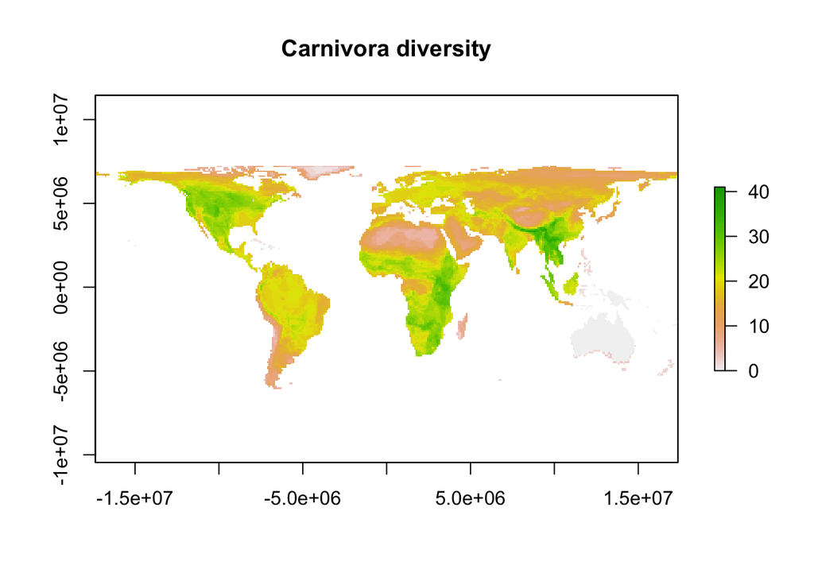

```r
transformed_world = st_transform(world_map,projection(raster))
world_spatial <- as(transformed_world, 'Spatial')
diversity_raster = mask(raster,world_spatial)
plot(diversity_raster,main='Carnivora diversity')
```

To get a better understanding of your species diversity raster, just print the raster object to screen :

```
## class       : RasterLayer
## dimensions  : 142, 360, 51120  (nrow, ncol, ncell)
## resolution  : 96486.27, 96514.96  (x, y)
## extent      : -17367529, 17367529, -6356742, 7348382  (xmin, xmax, ymin, ymax)
## coord. ref. : +proj=cea +lon_0=0 +lat_ts=30 +x_0=0 +y_0=0 +datum=WGS84 +units=m +no_defs +ellps=WGS84 +towgs84=0,0,0
## data source : in memory
## names       : layer
## values      : 0, 41  (min, max)
```

Check the dimension of you raster using the `dim()` command, which tells you how many cells the raster contains along the x and y axis.

```r
dim(diversity_raster)
```

```
## [1] 142 360   1
```

And the resolution of the raster:

```r
res(diversity_raster)
```

```
## [1] 96486.27 96514.96
```

You can get an idea of the coordinate system your raster data is stored in by checking the extent of the raster:

```r
extent(diversity_raster)
```

```
## class       : Extent
## xmin        : -17367529
## xmax        : 17367529
## ymin        : -6356742
## ymax        : 7348382
```

This is how you check the projection of the cluster:

```r
projection(diversity_raster)
```

```
## [1] "+proj=cea +lon_0=0 +lat_ts=30 +x_0=0 +y_0=0 +datum=WGS84 +units=m +no_defs +ellps=WGS84 +towgs84=0,0,0"
```

Note that the mammal diversity data is in CEA format

### Predictor data

Now it’s time to load the data for the predictor variables, which are the factors we want to test for correlation with mammalian species diversity. You can download whatever variables you want to check (for example get annual precitipitation data if you want to test if precipitation is a predictor of species diversity). A lot of useful climatic data can be found at http://chelsa-climate.org/bioclim/, but feel free to use any data source you want to. In this example I will work with annual average precipitation grid data, but you should preferably chose a different variable to test:

```r
precipitation_file = '../data/CHELSA_bio10_12.tif'
precipitation_raster = raster(precipitation_file)
#plot(precipitation_raster,main='Precipitation')
precipitation_raster
```

```
## class       : RasterLayer
## dimensions  : 20880, 43200, 902016000  (nrow, ncol, ncell)
## resolution  : 0.008333333, 0.008333333  (x, y)
## extent      : -180.0001, 179.9999, -90.00014, 83.99986  (xmin, xmax, ymin, ymax)
## coord. ref. : +proj=longlat +datum=WGS84 +no_defs +ellps=WGS84 +towgs84=0,0,0
## data source : /Users/tobias/GitHub/spatial_R_course/data/CHELSA_bio10_12.tif
## names       : CHELSA_bio10_12
## values      : -32768, 32767  (min, max)
```

If you are using bioclim data you’ll see that the resolution of the raster is incredibly high, which makes for very slow processing times for all operations on the raster. Let’s therefore first reduce the data to a lower resolution.

If you want to rescale your raster to a coarser resolution you can use the `aggregate()` function. Say you want to change the resolution of your raster to roughly 0.1 grid size (approx. 10x10km cell-size at the equator), you can rescale the raster by factor `0.1/res(precipitation_raster)`. Note that the aggregate function only accepts integer values. If a factor is provided that is not an integer but a float, the function will round it to the closest integer value. This command will take around 10 minutes to finish.

```r
# round the values of the extent of this raster to integers
extent(precipitation_raster) = round(extent(precipitation_raster))
precipitation_raster_reduced = aggregate(precipitation_raster, fact = 0.1/res(precipitation_raster))
precipitation_raster_reduced
```

```
## class       : RasterLayer
## dimensions  : 1740, 3600, 6264000  (nrow, ncol, ncell)
## resolution  : 0.1, 0.1  (x, y)
## extent      : -180, 180, -90, 84  (xmin, xmax, ymin, ymax)
## coord. ref. : +proj=longlat +datum=WGS84 +no_defs +ellps=WGS84 +towgs84=0,0,0
## data source : /private/var/folders/13/rrlwnj8d3fn76tbz9yfcv0kr0000gn/T/RtmpW0YChQ/raster/r_tmp_2020-05-26_220248_90596_02501.grd
## names       : CHELSA_bio10_12
## values      : 0, 10226.51  (min, max)
```

Compare the difference in dimensions between the original raster and the reduced one.

```r
dim(precipitation_raster)
```

```
## [1] 20880 43200     1
```

```r
dim(precipitation_raster_reduced)
```

```
## [1] 1740 3600    1
```

We need to make sure that our predictor data (precipitation) is in the same projection as the response variable data (species diversity).

It makes most sense to project all data into the CEA projection, since this will optimize the cells towards having a close to equal area. If we wouldn’t optimize for equal area but instead use the Mercator projection (lon-lat), our species diversity values would be biased toward the equator where cells would be bigger than toward the poles and would therefore inflate the values of species diversity the bigger the cell is. Using the CEA projection instead minimizes this bias. However some bias remains as it is impossible to project a globe into perfectly equal sized grid cells.

We try to further optimize the size-equality of our cells by picking the reference point of latitude=30 for our projection. The further a grid cell is away from this latitude, the smaller it’s area is going to be. Since most of the global landmass is in the Northern hemisphere, picking this latitude is usually the best solution for global analyses. If however you find yourself working on spatial data only pertaining to South America, you may consider picking a different latitude (e.g. the equator at latitude=0). The way to code our desired projection (CEA, centered at latitude=30) is `"+proj=cea +datum=WGS84 +lat_ts=30"`.

```r
precipitation_data_cea = projectRaster(precipitation_raster_reduced,crs="+proj=cea +datum=WGS84 +lat_ts=30")
```

**To remind you what we just did:** - we loaded the raw climate data raster, which had a very high resolution - we reduced the resolution of the raster with `aggregate()` to roughly have 10x10km grid size - we projected the raster into the CEA projection, using `projectRaster()`

To demonstrate the difference between the two projections, plot the raster in both projections and compare e.g. the size of Greenland in relation to areas around the equator:

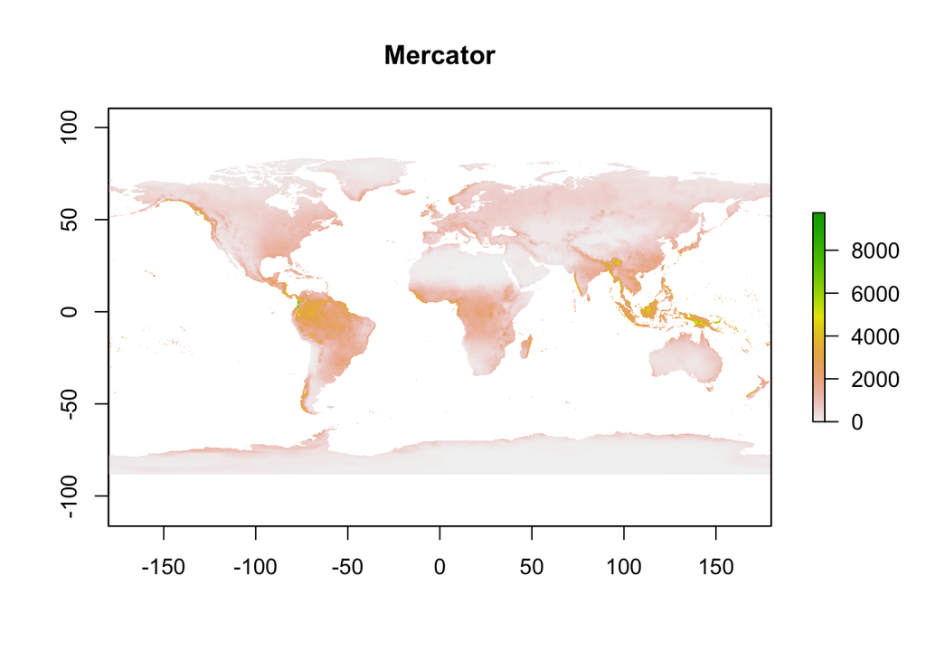

```r
plot(precipitation_raster_reduced,main='Mercator')
```

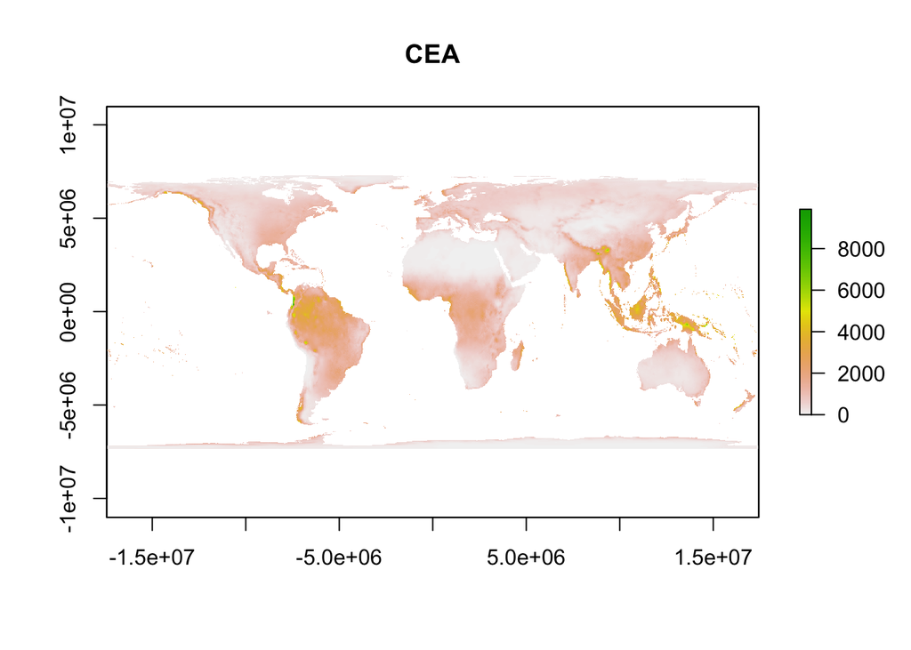

```r
plot(precipitation_data_cea,main='CEA')
```

Also, notice how the resolution of your raster has changed too by transforming it into another projection. This is expected because the cells of the raster are being restructured and altered in size when changing from one projection into another.

```r
print(dim(precipitation_raster_reduced))
```

```
## [1] 1740 3600    1
```

```r
print(dim(precipitation_data_cea))
```

```
## [1] 1163 3613    1
```

### Matching the spatial data

Now we need to make sure that we have the exact same number of cells (rows and columns) for our response variable and predictor variables, in order to be able to match each spatial biodiversity value with a predictor variable value.

```r
print(dim(diversity_raster))
```

```
## [1] 142 360   1
```

```r
print(dim(precipitation_data_cea))
```

```
## [1] 1163 3613    1
```

We can use the `resample()` function to match the dimensions of one raster to those of another. However, since our `diversity_raster` has a much lower resolution, and we would be producing spatial biases when just resampling values from our higher resolution raster based on the dimensions of this lower resolution raster, it is good practice to simply increase the dimensions of the reference raster (`diversity_raster` in our case) by dividing existing cells into multiple cells with the same exact value using `disaggregate()` to roughly match the dimensions of the target raster (`precipitation_data_cea`). Therefore we will first inflate the number of cells in the `diversity_raster` by factor 10, then match the dimensions of the precipitation raster to that of the inflated diversity raster with `resample()` and then reduce the resolution of the resampled precipitation raster by factor 10 (with `aggregate()`) to get it to exactly match the original diversity raster. If this doens’t make sense to you have a look at the slides about the resampling process and feel free to ask us if this is still unclear.

```r
diversity_raster_dis = disaggregate(diversity_raster,10)
precipitation_data_matched_10 = resample(precipitation_data_cea, diversity_raster_dis, method='bilinear')
precipitation_data_matched = aggregate(precipitation_data_matched_10, 10)
```

Let’s see if it worked:

```r
print(dim(diversity_raster))
```

```
## [1] 142 360   1
```

```r
print(dim(precipitation_data_matched))
```

```
## [1] 142 360   1
```